# Practical Machine Learning Project

Akshaya Padhi

April 30, 2017

## Prediction Assignment

### Background

Using devices such as JawboneUp, NikeFuelBand, and Fitbitit is now possible to collect a large amount of data about personal activity relatively inexpensively. These type of devices are part of the quantified self movement - a group of enthusiasts who take measurements about themselves regularly to improve their health, to find patterns in their behavior, or because they are tech geeks. One thing that people regularly do is quantify how much of a particular activity they do, but they rarely quantify how well they do it.

In this project, the goal is to use data from accelerometers on the belt, forearm, arm, and dumbell of 6 participants. They were asked to perform barbell lifts correctly and incorrectly in 5 different ways. More information is available from the website: http://groupware.les.inf.puc-rio.br/har (see the section on the Weight Lifting Exercise Dataset).

### Preparing the data and R packages

#### Load packages

```r
library(gbm)
library(survival)
library(splines)
library(parallel)
library(plyr)
library(dplyr);
library(tidyr);
library(ggplot2);
library(caret);
library(rpart);
library(rpart.plot);
library(RColorBrewer);
library(rattle);
library(randomForest);
library(knitr);
library(corrplot)
knitr::opts_chunk$set(cache=TRUE)
```

#### Getting Data

```r
# URL of the training and testing data
trainUrl <- "http://d396qusza40orc.cloudfront.net/predmachlearn/pml-training.csv"
testUrl <- "http://d396qusza40orc.cloudfront.net/predmachlearn/pml-testing.csv"

#Data Download
trainingData <- tbl_df(read.csv(url(trainUrl), na.strings=c("NA","#DIV/0!","")))
testingData <- tbl_df(read.csv(url(testUrl), na.strings=c("NA","#DIV/0!","")))
dim(trainingData)
```

```
## [1] 19622   160
```

```r
dim(testingData)
```

```
## [1]  20 160
```

The raw training data has 19622 rows of observations and 158 features (predictors). Column `X` is unusable row number. While the testing data has 20 rows and the same 158 features. There is one column of target outcome named `classe`.

#### Data cleaning

- First, Thake the colums with 70% or more NA values.
- Take out the columns with Near Zero Variance.
- After that Remove the fist six columns whish are not predictors.
- Keep only the selected columns in the test data. Ofcousre take out the outcome column from Test data.

```r
training<-trainingData[,colMeans(is.na(trainingData)) < 0.7] # Columns with >70% NA values
nzv <- nearZeroVar(training, saveMetrics=TRUE)
training <- training[,nzv$nzv==FALSE]           # Remove NearZero variance predictors
training <- training[ , -c(1:6)]                      # Remove Non- prediction columns
testData<- testingData[, colnames(training[ , -53])]      # Keep only prediciton columns in TestData
dim(training)
```

```
## [1] 19622    53
```

```r
dim(testData)
```

```
## [1] 20 52
```

### Build machine learning model

Now build a machine learning model to predict activity quality (`classe` outcome) from the activity monitors (the features or predictors)

##### Data prep

```r
# convert data to matrix
set.seed(825)
inTrain <- createDataPartition(training$classe, p=0.7, list=FALSE)
myTraining <- training[inTrain, ]
myValidation <- training[-inTrain, ]
dim(myTraining); dim(myValidation)
```

```
## [1] 13737    53
```

```
## [1] 5885   53
```

#### Prediction Models

##### Prediction Models: LDA

```r
fitControl <- trainControl(method = "repeatedcv",number = 5,repeats = 1)
modLda <- train(classe~., method="lda", data = myTraining, trControl = fitControl,
                      verbose = FALSE)
predLda <- predict(modLda, newdata=myValidation)
confMatLda <- confusionMatrix(predLda, myValidation$classe)
accuracyLda<-round(confMatLda$overall[1], 3);
outOfSampErrLda<- round(1- confMatLda$overall[1], 3)
writeLines("Accuracy and Out of sample Error \n")
```

```
## Accuracy and Out of sample Error
```

```r
paste("Accuracy = ", accuracyLda)
```

```
## [1] "Accuracy =  0.695"
```

```r
paste("Out of Sample Error =", outOfSampErrLda)
```

```
## [1] "Out of Sample Error = 0.305"
```

```r
writeLines("\n Prediction Table \n")
```

```
##
##  Prediction Table
```

```r
confMatLda$table
```

```
##           Reference
## Prediction    A    B    C    D    E
##          A 1366  176   98   61   46
##          B   36  721   97   38  190
##          C  134  144  680  121  108
##          D  133   39  126  696  112
##          E    5   59   25   48  626
```

##### Prediction Models: GBM

```r
modGbm <- train(classe ~ ., data=myTraining, method = "gbm",
                trControl = fitControl,
                verbose = FALSE)

predGbm <- predict(modGbm, newdata=myValidation)
confMatGbm <- confusionMatrix(predGbm, myValidation$classe)
accuracyGbm<-round(confMatGbm$overall[1], 3);
outOfSampErrGbm<- round(1- confMatGbm$overall[1], 3)
writeLines("Accuracy and Out of sample Error \n")
```

```
## Accuracy and Out of sample Error
```

```r
paste("Accuracy = ", accuracyGbm)
```

```
## [1] "Accuracy =  0.959"
```

```r
paste("Out of Sample Error =", outOfSampErrGbm)
```

```
## [1] "Out of Sample Error = 0.041"
```

```r
writeLines("\n Prediction Table \n")
```

```
##
##  Prediction Table
```

```r
confMatGbm$table
```

```
##           Reference
## Prediction    A    B    C    D    E
##          A 1646   45    0    1    2
##          B   17 1054   35    6   15
##          C    4   38  980   26    9
##          D    6    2   11  924   14
##          E    1    0    0    7 1042
```

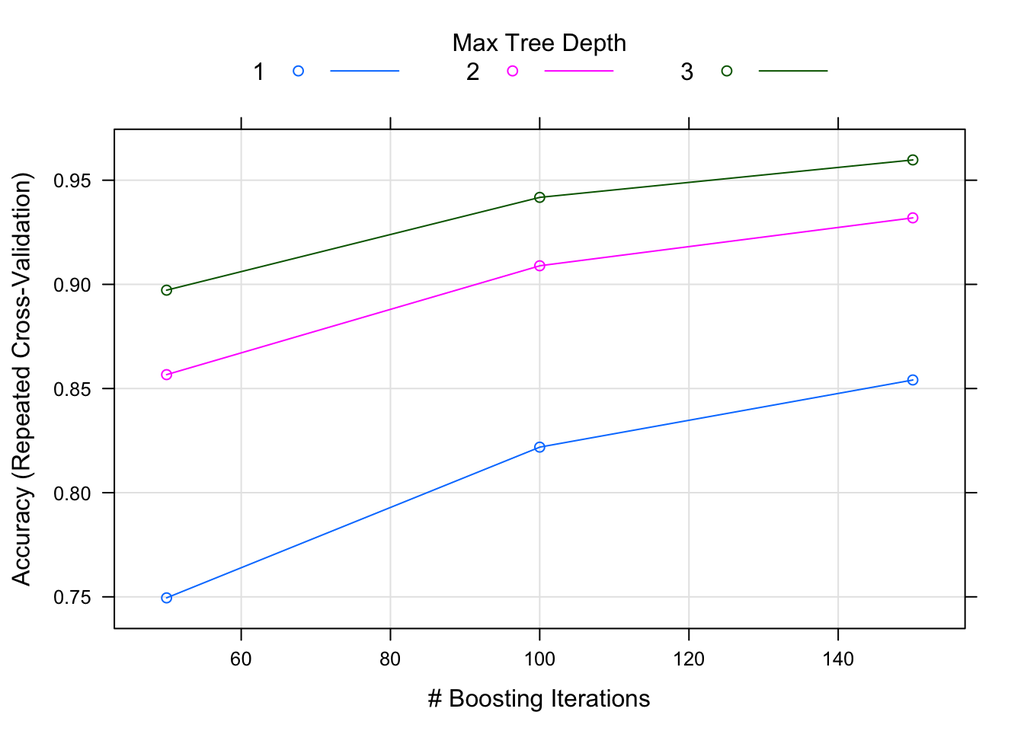

```r
plot(modGbm)
```

```r
set.seed(825)
modRf <- randomForest(classe~., data = myTraining, trControl = fitControl,
                      verbose = FALSE)
predRf<-predict(modRf, myValidation)
confMatRf <- confusionMatrix(predRf, myValidation$classe)
accuracyRf<-round(confMatRf$overall[1], 3);
outOfSampErrRf<- round(1- confMatRf$overall[1], 3)

writeLines("\n Accuracy and Out of sample Error \n")
```

```
##
##  Accuracy and Out of sample Error
```

```r
paste("Accuracy = ", accuracyRf)
```

```
## [1] "Accuracy =  0.995"
```

```r
paste("Out of Sample Error =", outOfSampErrRf)
```

```
## [1] "Out of Sample Error = 0.005"
```

```r
writeLines("\n Prediction Table \n")
```

```
##
##  Prediction Table
```

```r
confMatRf$table
```

```
##           Reference
## Prediction    A    B    C    D    E
##          A 1671    4    0    0    0
##          B    2 1132    3    0    0
##          C    0    3 1023   11    3
##          D    0    0    0  952    4
##          E    1    0    0    1 1075
```

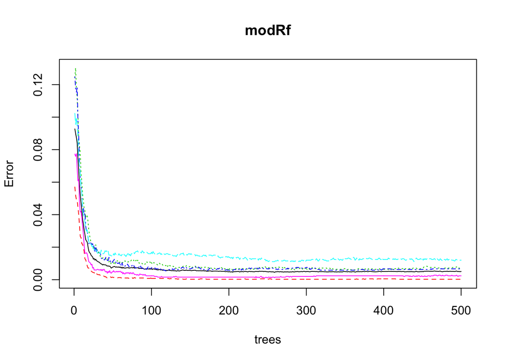

```r
plot(modRf)
```

#### Predicting the testing data

```r
predRf <- predict(modRf, testData)
predRf
```

```
##  1  2  3  4  5  6  7  8  9 10 11 12 13 14 15 16 17 18 19 20
##  B  A  B  A  A  E  D  B  A  A  B  C  B  A  E  E  A  B  B  B
## Levels: A B C D E
```